# sub_saharan_africa_esperance

AKANHO_Naofal

2025-01-30

# 1 Introduction

L’espérance de vie est un indicateur fondamental du développement humain, reflétant la qualité de vie, l’accès aux soins de santé et les conditions socio-économiques d’une population. Dans les pays d’Afrique subsaharienne, cet indicateur varie considérablement en raison de multiples facteurs, notamment l’accès aux infrastructures médicales, les niveaux d’éducation, le revenu par habitant et l’impact des maladies infectieuses. Cette étude vise à analyser les déterminants de l’espérance de vie dans cette région, en exploitant un ensemble de données issues de sources fiables. À travers des méthodes d’analyse statistique et de modélisation, nous chercherons à identifier les variables les plus influentes et à dégager des tendances pouvant orienter les politiques publiques en matière de santé et de développement.

# 2 Matériels et Méthodes

1. Données :

**Source** : Kaggle : https://www.kaggle.com/datasets/mjshri23/life-expectancy-and-socio-economic-world-bank

**Région étudiée** : Afrique subsaharienne

Observations : Données filtrées sur plusieurs années et pays

Variables disponibles : indicateurs économiques, environnementaux et sanitaires

2. Description des variables
- **Country Name** : Nom du pays
- **IncomeGroup** : Classe de revenu du pays
- **Year** : Année (2001 à 2019 inclut)
- **Life Expectancy World Bank** : Espérance de vie
- **Prevalence of Undernourishment** : La prévalence de la sous-alimentation est le pourcentage de la population dont la consommation alimentaire habituelle est insuffissante pour fournir les niveaux d’énergie alimentaire nécessaires au maintien d’une vie normalement active et saine
- **CO2** : Émissions de CO₂(Celles qui proviennent de la combustion de combustibles fossiles et de la fabrication de ciment)
- **Health Expenditure %** : Dépenses de santé en % du PIB
- **Unemployment** : Le chômage fait référence à la part en pourcentage de la population active qui est sans travail mais disponible et à la recherche d’un emploi.
- **Injuries (Blessures)** : Les AVCI dues aux blessures représentent la perte de santé en raison des blessures, qu’elles soient causées par des accidents, des traumatismes ou d’autres causes.
- **Communicable** **(Maladies Transmissibles)** : Les AVCI dues aux maladies transmissibles incluent les maladies infectieuses, telles que le paludisme, la tuberculose ou le VIH/SIDA.
- **NonCommunicable (Maladies Non Transmissibles)** : Les AVCI dues aux maladies non transmissibles incluent des maladies chroniques comme le diabète, les maladies cardiovasculaires et les cancers.

**AVCI** : **Années de Vie Corrigées de l’Incapacité**

L’**AVCI** (**Disability-Adjusted Life Years - DALY** en anglais) est une **mesure de la charge globale de morbidité** dans une population. Elle représente **la perte totale d’années de vie en bonne santé** due à une maladie, une blessure ou un problème de santé.

**Formule de l’AVCI** :

**AVCI = AVP + AVI**

où :

- **AVP (Années de Vie Perdues)** → Années perdues à cause d’un décès prématuré.
- **AVI (Années Vécues avec une Incapacité)** → Années vécues avec une maladie ou une incapacité qui réduit la qualité de vie.

### 2.0.1 🔹 **Comment interpréter l’AVCI ?**

- **1 AVCI = 1 année de vie en bonne santé perdue.**
- Plus l’AVCI est **élevé**, plus la maladie ou l’accident a un **impact négatif** sur la santé publique.
- L’AVCI permet aux chercheurs et aux décideurs de **comparer l’impact** de différentes maladies sur une population.

### 2.0.2 🔹 **Exemples concrets**

📌 **Un accident grave** :

- Une personne devient paralysée après un accident de voiture à **30 ans** et vit jusqu’à **70 ans**.
- Elle perd **40 années de vie en bonne santé** à cause du handicap → **40 AVCI**.

📌 **Une maladie infectieuse** (ex : paludisme) :

- Si **1000 personnes** meurent prématurément à **40 ans** au lieu de **70 ans**, cela représente **30 000 AVP**.
- Si **5000 personnes** souffrent de séquelles pendant **5 ans** avec un impact modéré (0.5 de gravité), cela fait **12 500 AVI**.
- **AVCI total** = 30 000 + 12 500 = **42 500 AVCI**.

# 3 Code et Discussions

## 3.1 Chargement des données

```r
library(readr)
library(car)
data <- read_csv("data.csv", show_col_types = FALSE)
```

## 3.2 Exploration des données

### 3.2.1 Vérification des valeurs manquantes

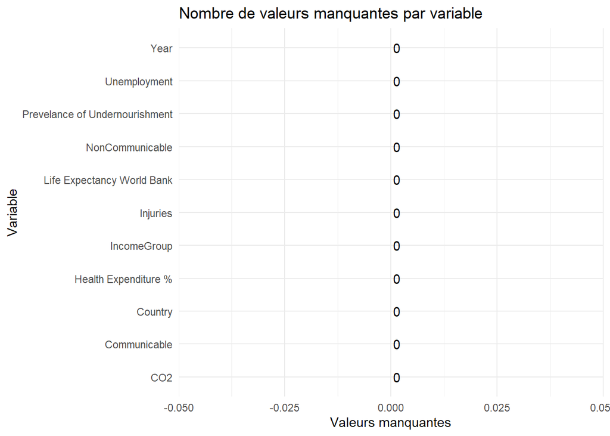

```r
library(ggplot2)

# Calculer le nombre de valeurs manquantes par colonne
missing_data <- data.frame(
  variable = names(data),
  missing_count = colSums(is.na(data))
)

# Barplot avec annotations des valeurs manquantes
ggplot(missing_data, aes(x = reorder(variable, -missing_count), y = missing_count)) +
  geom_bar(stat = "identity", fill = "skyblue") +
  geom_text(aes(label = missing_count), hjust = -0.3, color = "black") +  # Ajouter le texte
  labs(title = "Nombre de valeurs manquantes par variable", x = "Variable", y = "Valeurs manquantes") +
  theme_minimal() +
  coord_flip()  # Inverser les axes
```

**Constat** : Il y a pas de valeurs manquantes.

```r
dim(data)
```

```
## [1] 589  11
```

```r
# Nombre de pays (N)
library(dplyr)
N <- data %>%
  distinct(`Country`) %>%
  nrow()

# Nombre d'années (T)
T <- data %>%
  distinct(Year) %>%
  nrow()

# Affichage des résultats
cat("Nombre de pays (N) :", N, "\n")
```

```
## Nombre de pays (N) : 31
```

```r
cat("Nombre d'années (T) :", T, "\n")
```

```
## Nombre d'années (T) : 19
```

```r
cat("Taille totale du panel (N x T) :", N * T, "\n")
```

```
## Taille totale du panel (N x T) : 589
```

### 3.2.2 Statistiques descriptives

```r
summary(data)
```

```
##    Country          IncomeGroup             Year
##  Length:589         Length:589         Min.   :2001
##  Class :character   Class :character   1st Qu.:2005
##  Mode  :character   Mode  :character   Median :2010
##                                        Mean   :2010
##                                        3rd Qu.:2015
##                                        Max.   :2019
##  Life Expectancy World Bank Prevelance of Undernourishment      CO2
##  Min.   :40.37              Min.   : 3.10                  Min.   :    50
##  1st Qu.:52.31              1st Qu.:10.60                  1st Qu.:  1040
##  Median :57.97              Median :17.60                  Median :  3570
##  Mean   :57.52              Mean   :20.02                  Mean   : 20876
##  3rd Qu.:62.62              3rd Qu.:28.50                  3rd Qu.:  7450
##  Max.   :74.51              Max.   :67.50                  Max.   :447930
##  Health Expenditure %  Unemployment       Injuries        Communicable
##  Min.   : 2.385       Min.   : 0.600   Min.   :   3268   Min.   :    16170
##  1st Qu.: 3.753       1st Qu.: 3.030   1st Qu.: 118813   1st Qu.:  1360607
##  Median : 4.763       Median : 5.527   Median : 440064   Median :  5434699
##  Mean   : 5.537       Mean   : 8.807   Mean   : 824675   Mean   :  9939657
##  3rd Qu.: 6.845       3rd Qu.:13.821   3rd Qu.: 917065   3rd Qu.: 10403165
##  Max.   :20.413       Max.   :34.635   Max.   :5966517   Max.   :103785391
##  NonCommunicable
##  Min.   :   24499
##  1st Qu.:  468017
##  Median : 1993660
##  Mean   : 3499101
##  3rd Qu.: 3845106
##  Max.   :31050076
```

**Observations** :

1. **Year** : Les années vont de 2001 à 2019. La médiane et la moyenne sont 2010, indiquant une répartition uniforme des données sur cette période.

2. **Life Expectancy World Bank (Espérance de vie)** : L’espérance de vie minimale est de 40,37 ans, tandis que la maximale est de 74,51 ans. La moyenne est de 57,52 ans, avec un premier quartile à 52,31 ans, ce qui montre que la majorité des pays a une espérance de vie inférieure à 60 ans.

3. **Prevalence of Undernourishment (Prévalence de la sous-alimentation)** : La sous-alimentation varie fortement, de 3,10 % à 67,50 %, avec une moyenne de 20,02 %. Le premier quartile est à 10,60 %, donc 25 % des pays ont une prévalence de sous-alimentation très faible. En revanche, la valeur maximale (67,5 %) montre que certains pays sont sévèrement touchés par la faim.

4. **CO2 (Émissions de CO₂ en tonnes)** : Les émissions vont de 50 tonnes à un maximum de 447 930 tonnes, ce qui révèle une disparité importante entre les pays. La médiane est de 3 570 tonnes, indiquant que 50 % des pays émettent des quantités relativement faibles. Cependant, la moyenne est de 20 876 tonnes, influencée par des valeurs maximales très élevées.

5. **Health Expenditure % (Dépenses de santé en pourcentage du PIB)** : Les dépenses varient de 2,39 % à 20,41 %, avec une moyenne de 5,54 %. Le troisième quartile est à 6,85 %, indiquant que 75 % des pays dépensent moins de 7 % de leur PIB pour la santé.

6. **Unemployment (Chômage)** : Le taux de chômage varie de 0,6 % à 34,6 %. La médiane est de 5,53 %, mais la moyenne est plus élevée à 8,81 %, ce qui suggère que certains pays affichent des taux de chômage très élevés, influençant la moyenne.

7. **Injuries (Blessures)** : Le nombre de blessures va de 3 268 à 5 966 517. La médiane est de 440 064, et la moyenne est de 824 675, encore une fois influencée par quelques pays ayant des valeurs extrêmement élevées.

8. **Communicable (Maladies transmissibles)** : Les maladies transmissibles varient de 16 170 à 103 785 391. La médiane est de 5 434 699, ce qui indique que la majorité des pays ont des charges significatives de maladies transmissibles.

9. **NonCommunicable (Maladies non transmissibles)** : Ces maladies vont de 24 499 à 31 050 076. La médiane est de 1 993 660, montrant que les maladies non transmissibles représentent une charge importante dans la plupart des pays.

**On peut conclure** :

**Disparités importantes** : Les données montrent de grandes disparités entre les pays, notamment en termes de CO₂, chômage, et santé.

**Inégalités de santé** : La prévalence de la sous-alimentation et l’espérance de vie varient fortement, ce qui reflète des inégalités importantes.

**Charge de maladies** : Les maladies transmissibles dominent dans certains pays, mais les maladies non transmissibles sont aussi préoccupantes.

## 3.3 Préparer les données pour l’analyse de panel :

```r
library(dplyr)

panel_data <- data %>%
  mutate(
    `Country` = as.factor(Country),  # Convertir en facteur (correct)
    IncomeGroup = as.factor(IncomeGroup),
    Year = as.numeric(Year)
  )
```

## 3.4 Transformer les Données en Format Panel

```r
library(plm)
colnames(panel_data) <- gsub(" ", "_", colnames(panel_data))
panel_data <- pdata.frame(panel_data, index = c("Country", "Year"))
```

## 3.5 Visualisations Exploratoires

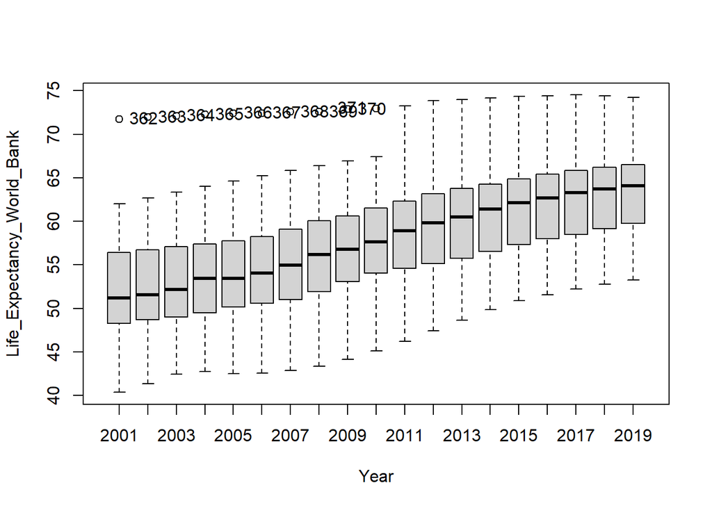

```
##  [1] "362" "363" "364" "365" "366" "367" "368" "369" "370" "371"
```

```r
scatterplot(Life_Expectancy_World_Bank ~ Year | Country, boxplots=FALSE, smooth=TRUE, reg.line=FALSE, data=panel_data)
```

**Observation** :

L’espérance de vie a tendance à augmenter progressivement au fil des années. La médiane (ligne dans chaque boîte) montre une hausse constante.

**Présence d’outliers** :

- Il y a des valeurs aberrantes (outliers) visibles en haut du graphique.
- Ces valeurs semblent être des pays ayant une espérance de vie très élevée par rapport à la majorité.

**Conclusion** :

L’espérance de vie suit une tendance haussière sans fluctuations majeures.

### 3.5.2 **Plotmeans pour détecter l’hétérogénéité à travers les pays**

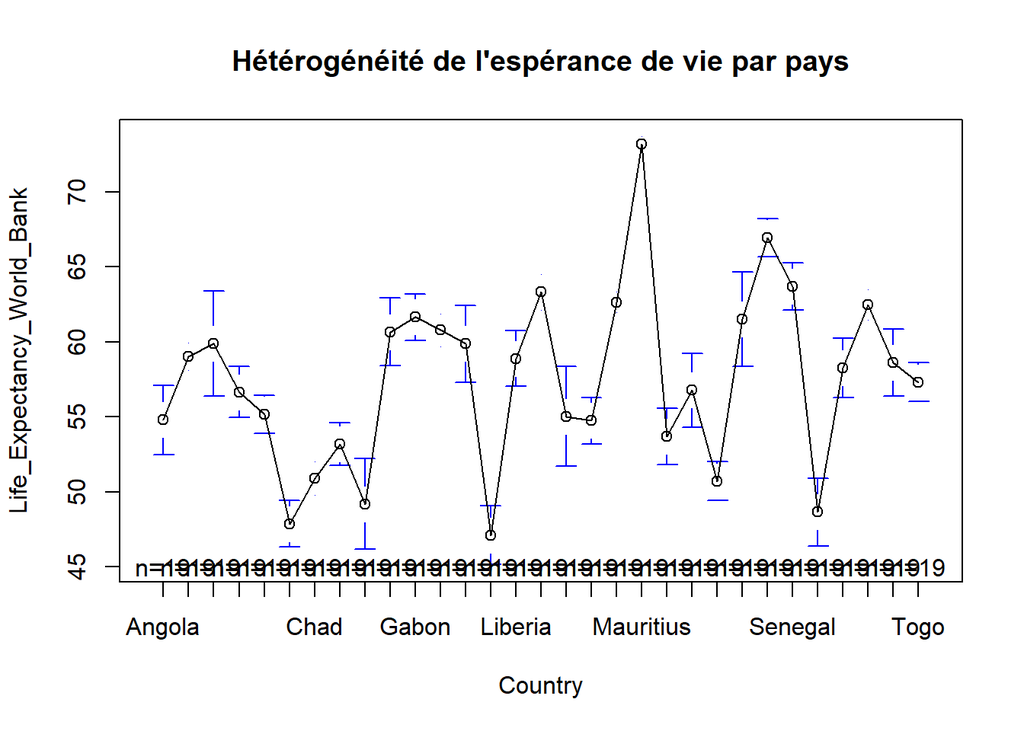

```r
library(gplots)
plotmeans(Life_Expectancy_World_Bank ~ Country, main="Hétérogénéité de l'espérance de vie par pays", data=panel_data)
```

**Observation** :

L’espérance de vie varie fortement d’un pays à l’autre.

On peut soupçonner des effets spécifiques entre les pays.

### 3.5.3 **Plotmeans pour détecter l’hétérogénéité à travers les années**

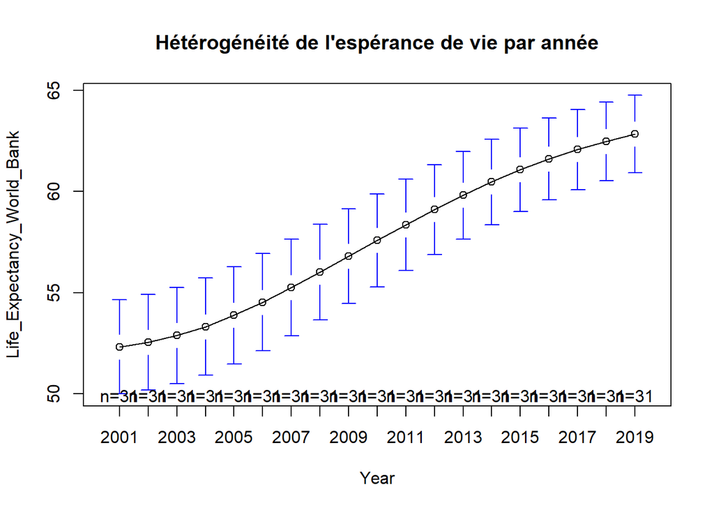

```r
plotmeans(Life_Expectancy_World_Bank ~ Year, main="Hétérogénéité de l'espérance de vie par année", data=panel_data)
```

**Observations :**

1. **Tendance générale** : L’espérance de vie montre une augmentation progressive de 2001 à 2019.
2. **Dispersion des données** : Les barres d’erreur (en bleu) indiquent une hétérogénéité de l’espérance de vie pour chaque année, suggérant une variabilité entre les pays d’Afrique subsaharienne.
3. **Évolution de la variabilité** : La dispersion semble être plus grande au début (2000-2010) et se réduit légèrement après 2010, ce qui pourrait indiquer une convergence progressive des espérances de vie entre les pays.

### 3.5.4 **Analyse de Corrélation**

#### 3.5.4.1 **Sélection des variables numériques pour l’analyse de corrélation**

```r
var_numerique = data %>%
  select(
    "Life Expectancy World Bank",
    "Prevelance of Undernourishment",
    CO2,
    "Health Expenditure %",
    Unemployment,
    Injuries,
    Communicable,
    NonCommunicable
  )
```

#### 3.5.4.2 **Calcul de la matrice de corrélation**

```r
cor_matrix <- cor(var_numerique, use = "complete.obs")
```

#### 3.5.4.3 **Affichage de la matrice de corrélation**

```r
print(cor_matrix)
```

```
##                                Life Expectancy World Bank
## Life Expectancy World Bank                    1.000000000
## Prevelance of Undernourishment               -0.323098509
## CO2                                           0.005735671
## Health Expenditure %                         -0.135512799
## Unemployment                                 -0.067283017
## Injuries                                     -0.104040873
## Communicable                                 -0.221022706
## NonCommunicable                              -0.077023654
##                                Prevelance of Undernourishment          CO2
## Life Expectancy World Bank                         -0.3230985  0.005735671
## Prevelance of Undernourishment                      1.0000000 -0.285418204
## CO2                                                -0.2854182  1.000000000
## Health Expenditure %                                0.1926384  0.144610889
## Unemployment                                       -0.3572606  0.366726665
## Injuries                                           -0.1575892  0.619094205
## Communicable                                       -0.1075774  0.311288433
## NonCommunicable                                    -0.1716397  0.432492536
##                                Health Expenditure % Unemployment   Injuries
## Life Expectancy World Bank               -0.1355128  -0.06728302 -0.1040409
## Prevelance of Undernourishment            0.1926384  -0.35726056 -0.1575892
## CO2                                       0.1446109   0.36672667  0.6190942
## Health Expenditure %                      1.0000000   0.30762948 -0.1379556
## Unemployment                              0.3076295   1.00000000 -0.0311730
## Injuries                                 -0.1379556  -0.03117300  1.0000000
## Communicable                             -0.1915543  -0.19263300  0.8708427
## NonCommunicable                          -0.1867058  -0.13620962  0.9465249
##                                Communicable NonCommunicable
## Life Expectancy World Bank       -0.2210227     -0.07702365
## Prevelance of Undernourishment   -0.1075774     -0.17163971
## CO2                               0.3112884      0.43249254
## Health Expenditure %             -0.1915543     -0.18670578
## Unemployment                     -0.1926330     -0.13620962
## Injuries                          0.8708427      0.94652490
## Communicable                      1.0000000      0.94332531
## NonCommunicable                   0.9433253      1.00000000
```

#### 3.5.4.4 **Visualisation de la matrice de corrélation avec corrplot**

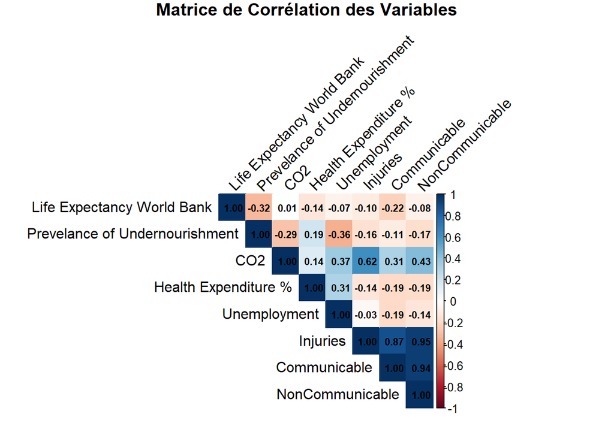

```r
library(corrplot)
corrplot(cor_matrix, method = "color", type = "upper",
         tl.col = "black", tl.srt = 45,
         addCoef.col = "black", # Ajoute les coefficients
         number.cex = 0.7,
         title = "Matrice de Corrélation des Variables",
         mar = c(0,0,1,0))
```

#### 3.5.4.6 Vérification et Quantification de la Multicolinéarité

```r
library(car)
vif(lm(Life_Expectancy_World_Bank ~ Injuries + Communicable + NonCommunicable +
         Prevelance_of_Undernourishment + CO2 + Health_Expenditure_. + Unemployment,
       data = panel_data))
```

```
##                       Injuries                   Communicable
##                      22.496210                      10.247762
##                NonCommunicable Prevelance_of_Undernourishment
##                      26.781881                       1.528666
##                            CO2           Health_Expenditure_.
##                       3.546504                       1.341552
##                   Unemployment
##                       1.633350
```

**Observation :**

- **Injuries (22.5)**, **Communicable (10.2)** et **NonCommunicable (26.8)** ont des VIF très élevés (**> 10**), ce qui confirme une **forte multicolinéarité**.
- Les autres variables ont des VIF acceptables (**< 5**), donc elles ne posent pas de problème.

#### 3.5.4.7 Solution :

Plusieurs options s’offre à nous :

🔹 **1. Faire une somme des trois variables** (`Injuries + Communicable + NonCommunicable`)

💡 **Idée :** Tu crées une nouvelle variable comme étant la **somme brute** des trois.

📌 **Problèmes :**

- **Suppose que toutes les variables ont le même poids**, ce qui n’est pas forcément vrai.
- **Ne corrige pas la colinéarité**, car elle persiste toujours dans les données.
- **Ne tient pas compte des échelles différentes** (ex. `Injuries` pourrait être plus grand que `Communicable`, donc influencer plus le résultat).

📊 **Quand l’utiliser ?**  
✅ Si toutes les variables ont un **impact équivalent** et sont **exprimées dans la même unité**.  
❌ Si elles ont des corrélations élevées et des unités différentes, cela peut biaiser le modèle.

🔹 **2. Utiliser une PCA pour créer une nouvelle variable**

💡 **Idée :** La PCA va transformer les variables en **composantes principales**, en essayant de **maximiser la variance expliquée**.

📌 **Avantages :**

- **Corrige la colinéarité** en regroupant l’information de manière optimisée.
- **Attribue un poids différent à chaque variable** (selon leur importance statistique).
- **Standardise les variables** pour éviter qu’une seule variable domine la nouvelle composante.
- **Réduit la redondance** tout en conservant l’essentiel des informations.

📊 **Comment ça marche ?**  
La **première composante principale (PC1)** est une combinaison linéaire des trois variables, pondérée de manière optimale

🔹 **3. Utiliser la régression Ridge ou Lasso**

💡 **Idée :** Ces techniques pénalisent les variables trop corrélées, évitant d’en privilégier une seule

✅ **Option : Faire une Analyse en Composantes Principales (PCA) :** Regrouper ces variables en une seule composante

- Crée une **nouvelle variable unique** qui résume les trois (Injuries, Communicable et NonCommunicable).

```r
library(FactoMineR)
pca_result <- PCA(panel_data[, c("Injuries", "Communicable", "NonCommunicable")], scale.unit = TRUE)
```

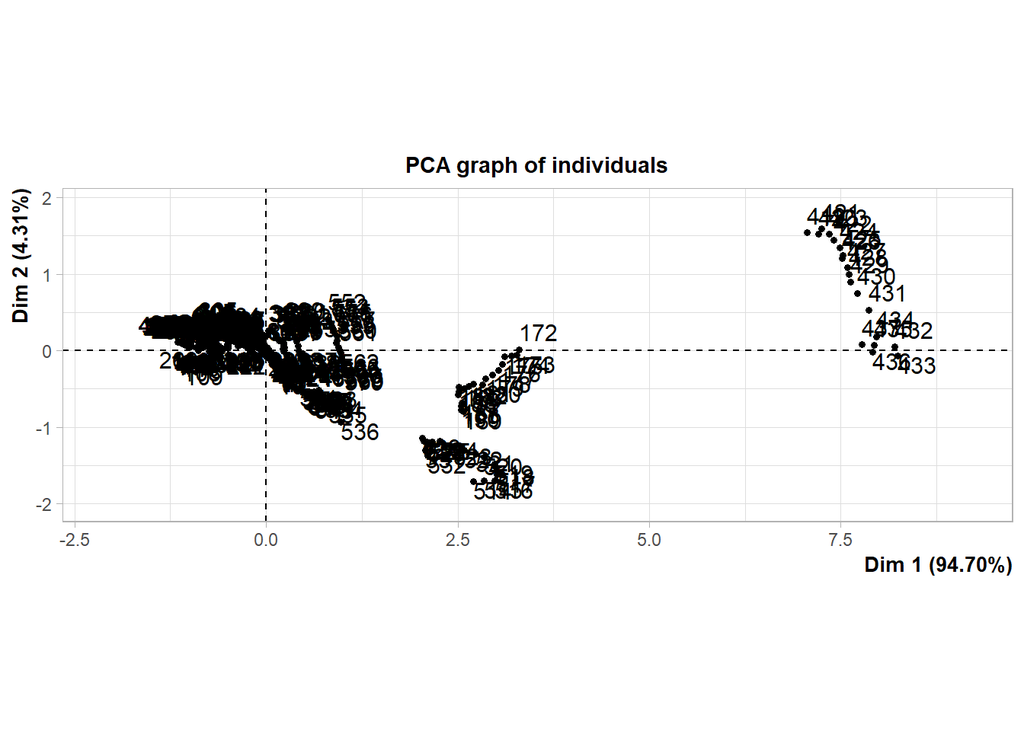

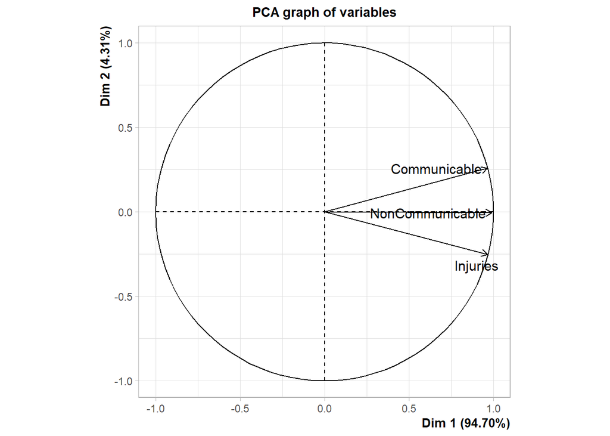

```r
pca_result
```

```
## **Results for the Principal Component Analysis (PCA)**
## The analysis was performed on 589 individuals, described by 3 variables
## *The results are available in the following objects:
##
##    name               description
## 1  "$eig"             "eigenvalues"
## 2  "$var"             "results for the variables"
## 3  "$var$coord"       "coord. for the variables"
## 4  "$var$cor"         "correlations variables - dimensions"
## 5  "$var$cos2"        "cos2 for the variables"
## 6  "$var$contrib"     "contributions of the variables"
## 7  "$ind"             "results for the individuals"
## 8  "$ind$coord"       "coord. for the individuals"
## 9  "$ind$cos2"        "cos2 for the individuals"
## 10 "$ind$contrib"     "contributions of the individuals"
## 11 "$call"            "summary statistics"
## 12 "$call$centre"     "mean of the variables"
## 13 "$call$ecart.type" "standard error of the variables"
## 14 "$call$row.w"      "weights for the individuals"
## 15 "$call$col.w"      "weights for the variables"
```

```r
pca_scores <- pca_result$ind$coord[,1]  # Première composante principale
panel_data$Health_Risk_Index <- pca_scores  # Nouvelle variable
```

📌 **Interprétation :**

- `Health_Risk_Index` est une **nouvelle variable** qui représente au mieux l’effet combiné de `Injuries`, `Communicable` et `NonCommunicable`, en tenant compte de leurs corrélations et pondérations.
- Cette nouvelle variable **réduit la dimensionnalité** tout en minimisant la perte d’information.

```r
library(car)
vif(lm(Life_Expectancy_World_Bank ~ Prevelance_of_Undernourishment + CO2 + Health_Expenditure_. + Unemployment+ Health_Risk_Index,
       data = panel_data))
```

```
## Prevelance_of_Undernourishment                            CO2
##                       1.358486                       1.732176
##           Health_Expenditure_.                   Unemployment
##                       1.298491                       1.611192
##              Health_Risk_Index
##                       1.535592
```

**Observation** : Le problème de multicolinéarité a été résolu.

Tous les VIF sont inférieurs à 5, ce qui signifie que le modèle ne présente plus de multicolinéarité problématique.

```r
numerique = panel_data %>%
  select(
    Life_Expectancy_World_Bank,
    Prevelance_of_Undernourishment,
    CO2,
    Health_Expenditure_.,
    Unemployment,
    Health_Risk_Index
  )
```

```r
matrix_correlation <- cor(numerique, use = "complete.obs")
```

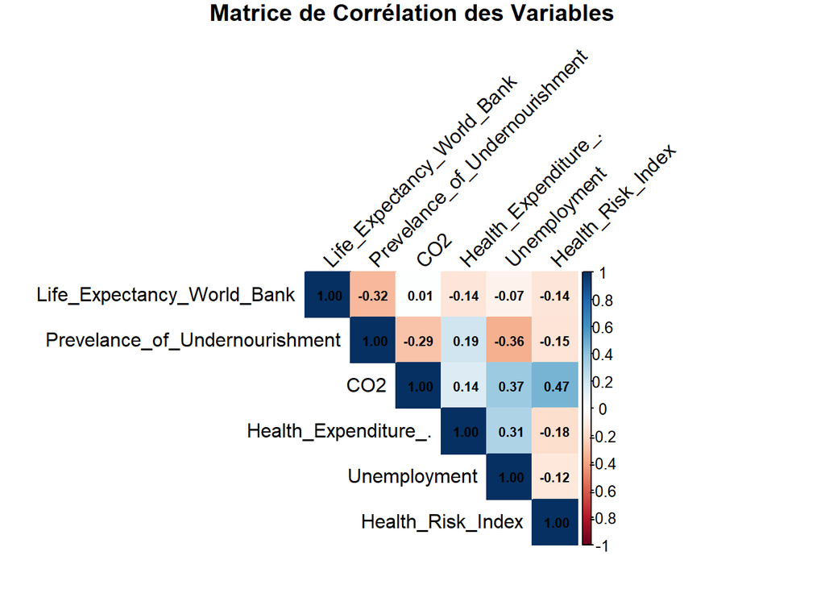

```r
library(corrplot)
corrplot(matrix_correlation, method = "color", type = "upper",
         tl.col = "black", tl.srt = 45,
         addCoef.col = "black", # Ajoute les coefficients
         number.cex = 0.7,
         title = "Matrice de Corrélation des Variables",
         mar = c(0,0,1,0))
```

### 3.5.5 Retrait des variables correlées

```r
library(dplyr)
panel <- panel_data %>%
  select(-Injuries, -Communicable, -NonCommunicable)
```

# 4 Modélisation :

## 4.1 Vérifier la stationnarité des variables

- Si toutes les variables sont stationnaires (I(0)), un **panel simple** est suffisant.
- Si certaines sont I(0)et d’autres I(1), alors un **ARDL panel** peut être plus adapté. ✅ **Si elles sont** I(1) et co-intégrées, on utilise un ARDL panel.  
  ✅ **Si elles sont** I(1) mais non co-intégrées, on peut penser à différencier ou utiliser un GMM.

  # Fonction pour tester la stationnarité avec ADF et KPSS
  test_stationnarite <- function(col) {
    adf_pvalue <- adf.test(panel[[col]], alternative = "stationary")$p.value

    adf_result <- ifelse(adf_pvalue < 0.05, "Stationnaire", "Non Stationnaire")

    return(data.frame(Variable = col, ADF = adf_result))
  }

  # Appliquer le test sur toutes les variables numériques
  resultats_stationnarite <- do.call(rbind, lapply(numerical_cols, test_stationnarite))
  # Afficher les résultats
  print(resultats_stationnarite)
  ```

  ```
  ##                         Variable          ADF
  ## 1     Life_Expectancy_World_Bank Stationnaire
  ## 2 Prevelance_of_Undernourishment Stationnaire
  ## 3                            CO2 Stationnaire
  ## 4           Health_Expenditure_. Stationnaire
  ## 5                   Unemployment Stationnaire
  ## 6              Health_Risk_Index Stationnaire
  ```

  **Conclusion** : Toute nos variables sont stationnaires, on peut effectuer un panel simple sur nos données.

## 4.2 **Estimation du modèle Pooled**

```r
pooled_model <- plm(Life_Expectancy_World_Bank ~
                      Prevelance_of_Undernourishment +
                      CO2 +
                      Health_Expenditure_. +
                      Unemployment +
                      Health_Risk_Index +
                      IncomeGroup,
                    data = panel,
                    model = "pooling")
summary(pooled_model)
```

```
## Pooling Model
##
## Call:
## plm(formula = Life_Expectancy_World_Bank ~ Prevelance_of_Undernourishment +
##     CO2 + Health_Expenditure_. + Unemployment + Health_Risk_Index +
##     IncomeGroup, data = panel, model = "pooling")
##
## Balanced Panel: n = 31, T = 19, N = 589
##
## Residuals:
##      Min.   1st Qu.    Median   3rd Qu.      Max.
## -11.59324  -4.90635  -0.53632   4.49598  14.63706
##
## Coefficients:
##                                   Estimate  Std. Error t-value  Pr(>|t|)
## (Intercept)                     6.4621e+01  9.0615e-01 71.3134 < 2.2e-16 ***
## Prevelance_of_Undernourishment -2.4633e-01  2.4870e-02 -9.9046 < 2.2e-16 ***
## CO2                             4.4277e-07  4.6120e-06  0.0960    0.9236
## Health_Expenditure_.            1.2302e-02  1.1329e-01  0.1086    0.9136
## Unemployment                   -4.0796e-01  4.2335e-02 -9.6364 < 2.2e-16 ***
## Health_Risk_Index              -9.2351e-01  1.8170e-01 -5.0825 5.030e-07 ***
## IncomeGroupLower middle income  1.7433e-01  6.2084e-01  0.2808    0.7790
## IncomeGroupUpper middle income  7.9131e+00  9.4940e-01  8.3349 5.623e-16 ***
## ---
## Signif. codes:  0 '***' 0.001 '**' 0.01 '*' 0.05 '.' 0.1 ' ' 1
##
## Total Sum of Squares:    28742
## Residual Sum of Squares: 19744
## R-Squared:      0.31304
## Adj. R-Squared: 0.30477
## F-statistic: 37.8228 on 7 and 581 DF, p-value: < 2.22e-16
```

### 4.2.1 📊 **Interprétation des résultats**

1. **Significativité des variables**
   - `Prevalence_of_Undernourishment` (**p < 2.2e-16**): Fortement significatif, impact négatif sur l’espérance de vie, ce qui suggère qu’une plus grande prévalence de la sous-alimentation est associée à une espérance de vie plus faible.
   - `Unemployment` (**p < 2.2e-16**): Négatif et significatif, donc plus de chômage réduit l’espérance de vie autrement dit des taux de chômage plus élevés sont associés à une espérance de vie plus courte.
   - `Health_Risk_Index` (**p = 5.030e-07**): Négatif et significatif, ce qui est logique,une valeur plus élevée de cet indice semble réduire l’espérance de vie.
   - `IncomeGroupUpper middle income` (**p = 5.623e-16**): Positif et significatif → un niveau de revenu plus élevé améliore l’espérance de vie autrement dit un groupe de revenu moyen supérieur est associé à une espérance de vie significativement plus élevée.
2. **Variables non significatives**
   - `CO2` (**p = 0.9236**) et `Health_Expenditure_.` (**p = 0.9136**) ne sont pas significatifs.
   - `IncomeGroupLower middle income` (**p = 0.7790**) n’a pas d’effet statistiquement prouvé.

Cela suggère que ces variables ne jouent pas un rôle direct significatif dans l’espérance de vie dans ce modèle.

3. **Qualité du modèle**
   - **R² = 0.313** → Seulement 31% de la variance de l’espérance de vie est expliquée. D’autres facteurs clés sont peut-être absents.
   - **F-statistique très significatif** p-value très faible (< 2.22e-16) → le modèle global est pertinent, c’est-à-dire que les variables prises ensemble ont un pouvoir explicatif pour l’espérance de vie.

**Conclusion** :

Les pays avec un revenu moyen supérieur (**IncomeGrouUppper middle income**) ont, en moyenne, une espérance de vie plus élevée(**Life_Expectancy_World_Bank**), ce qui est cohérent avec des niveaux de développement économique plus avancés. Le chômage(**Unemployment**), la sous-alimentation(**Prevelance_of_Undernourishment**) et l’indice de risque sanitaire(**Health_Risk_Index**) apparaissent comme des facteurs ayant un effet négatif important sur l’espérance de vie, et ces effets sont assez homogènes à travers les pays et les années.

La variabilité dans les données résiduelles (les résidus montrent une variation notable avec des valeurs allant de -11.59 à 14.64) suggère qu’il pourrait y avoir des effets spécifiques aux pays ou aux périodes non capturés dans ce modèle simple.

Un modèle avec des **effets fixes** ou **aléatoires** pourrait donner une meilleure vue d’ensemble sur les différences entre les pays et les années, en tenant compte de ces spécificités, en particulier si on est intéressé par l’évolution de l’espérance de vie au fil du temps pour chaque pays.

## 4.3 **Modèle à Effets Fixes (Fixed Effects) via dummies variables**

```r
fixed.dum = lm(Life_Expectancy_World_Bank ~
                      Prevelance_of_Undernourishment +
                      CO2 +
                      Health_Expenditure_. +
                      Unemployment +
                      Health_Risk_Index +
                      IncomeGroup + factor(Country), data = panel)
summary(fixed.dum)
```

```
##
## Call:
## lm(formula = Life_Expectancy_World_Bank ~ Prevelance_of_Undernourishment +
##     CO2 + Health_Expenditure_. + Unemployment + Health_Risk_Index +
##     IncomeGroup + factor(Country), data = panel)
##
## Residuals:
##      Min       1Q   Median       3Q      Max
## -10.0050  -1.9254  -0.0535   1.6266  10.4301
##
## Coefficients: (2 not defined because of singularities)
##                                           Estimate Std. Error t value Pr(>|t|)
## (Intercept)                              6.565e+01  1.597e+00  41.103  < 2e-16
## Prevelance_of_Undernourishment          -2.726e-01  2.521e-02 -10.813  < 2e-16
## CO2                                      1.424e-04  2.153e-05   6.616 8.74e-11
## Health_Expenditure_.                     5.519e-01  1.138e-01   4.848 1.62e-06
## Unemployment                            -3.711e-01  1.006e-01  -3.687 0.000249
## Health_Risk_Index                        3.900e+00  1.280e+00   3.048 0.002417
## IncomeGroupLower middle income          -5.151e+00  1.926e+00  -2.674 0.007717
## IncomeGroupUpper middle income          -6.801e+01  1.138e+01  -5.976 4.11e-09
## factor(Country)Benin                     2.043e+00  1.877e+00   1.089 0.276746
## factor(Country)Botswana                  7.560e+01  1.100e+01   6.873 1.70e-11
## factor(Country)Burkina Faso             -6.066e+00  1.489e+00  -4.074 5.29e-05
## factor(Country)Cameroon                 -3.955e+00  1.385e+00  -2.856 0.004446
## factor(Country)Central African Republic -4.765e+00  1.228e+00  -3.881 0.000117
## factor(Country)Chad                     -6.652e+00  1.288e+00  -5.164 3.38e-07
## factor(Country)Cote d'Ivoire            -5.161e+00  1.347e+00  -3.830 0.000143
## factor(Country)Eswatini                  1.505e+00  2.890e+00   0.521 0.602755
## factor(Country)Ethiopia                 -1.111e+01  4.857e+00  -2.287 0.022556
## factor(Country)Gabon                     7.690e+01  1.108e+01   6.942 1.09e-11
## factor(Country)Ghana                     1.229e+00  1.351e+00   0.910 0.363107
## factor(Country)Kenya                     1.104e+00  1.262e+00   0.875 0.381998
## factor(Country)Lesotho                   1.361e+00  2.990e+00   0.455 0.649202
## factor(Country)Liberia                   3.055e+00  1.245e+00   2.454 0.014419
## factor(Country)Madagascar                6.492e+00  1.365e+00   4.756 2.53e-06
## factor(Country)Malawi                   -6.019e+00  1.307e+00  -4.605 5.13e-06
## factor(Country)Mali                     -8.023e+00  1.529e+00  -5.247 2.20e-07
## factor(Country)Mauritania                1.001e+01  2.173e+00   4.605 5.13e-06
## factor(Country)Mauritius                 8.128e+01  1.147e+01   7.085 4.26e-12
## factor(Country)Mozambique               -6.842e+00  1.728e+00  -3.960 8.49e-05
```

[output cut: 40 more lines]

```
## factor(Country)Nigeria                  ***
## factor(Country)Rwanda                   **
## factor(Country)Sao Tome and Principe    ***
## factor(Country)Senegal                  ***
## factor(Country)Sierra Leone             ***
## factor(Country)South Africa
## factor(Country)Sudan
## factor(Country)Tanzania
## factor(Country)Togo
## ---
## Signif. codes:  0 '***' 0.001 '**' 0.01 '*' 0.05 '.' 0.1 ' ' 1
##
## Residual standard error: 3.424 on 553 degrees of freedom
## Multiple R-squared:  0.7745, Adjusted R-squared:  0.7602
## F-statistic: 54.26 on 35 and 553 DF,  p-value: < 2.2e-16
```

### 4.3.1 📊 **Interprétation des résultats**

1. **Intercept (Constante)**

- **Estimate**: 65.65
- **Interprétation**: Lorsque toutes les variables explicatives sont égales à zéro (ce qui peut ne pas avoir de sens concret ici, notamment pour les variables comme le pays), l’espérance de vie (Life_Expectancy_World_Bank) serait de 65.65. Cependant, cela n’a pas de réelle signification pratique, car cela implique un état fictif où toutes les autres variables sont nulles.

2. **Variables explicatives** :

3. **Effets fixes des pays (factor(Country))** :

- Les coefficients des pays représentent l’effet spécifique de chaque pays sur l’espérance de vie, par rapport au pays de référence qui est **Angola**.
- **Pays significatifs** : De nombreux pays comme le **Botswana**, **Gabon**, **Maurice**, **Sénégal**, **Sierra Leone** montrent des coefficients significatifs, suggérant que l’espérance de vie dans ces pays est statistiquement différente de la moyenne.
- **Pays non significatifs** : Certains pays comme **South Africa** et **Togo** ont des valeurs manquantes (NA), ce qui signifie que ces pays sont probablement exclus du modèle ou souffrent de multicolinéarité.

4. **Autres statistiques** :

- **Residual standard error (Erreur standard des résidus)** : 3.424, ce qui indique l’écart-type des erreurs de prédiction.
- **Multiple R-squared** : 0.7745, ce qui signifie que 77.45% de la variance de l’espérance de vie est expliquée par le modèle.
- **Adjusted R-squared** : 0.7602, qui ajuste R² en fonction du nombre de variables explicatives, offrant ainsi une meilleure estimation de la qualité du modèle.

5. **Significativité du modèle global** :

- **F-statistic** : 54.26 avec un p-value extrêmement faible (< 2.2e-16), indiquant que le modèle est significatif dans son ensemble.

**Conclusion** :

Le modèle montre que plusieurs facteurs, notamment la sous-nutrition, les émissions de CO2, les dépenses de santé et le chômage, influencent de manière significative l’espérance de vie. De plus, l’analyse des effets fixes par pays montre qu’il existe des différences significatives entre les pays en termes d’espérance de vie, ce qui justifie l’inclusion de ces effets pour contrôler les spécificités nationales.

## 4.4 **Modèle à Effets Fixes (Fixed Effects) via plm**

```r
fe_model <- plm(Life_Expectancy_World_Bank ~
                  Prevelance_of_Undernourishment +
                  CO2 +
                  Health_Expenditure_. +
                  Unemployment +
                  Health_Risk_Index +
                  IncomeGroup,
                data = panel,
                model = "within")
summary(fe_model)
```

```
## Oneway (individual) effect Within Model
##
## Call:
## plm(formula = Life_Expectancy_World_Bank ~ Prevelance_of_Undernourishment +
##     CO2 + Health_Expenditure_. + Unemployment + Health_Risk_Index +
##     IncomeGroup, data = panel, model = "within")
##
## Balanced Panel: n = 31, T = 19, N = 589
##
## Residuals:
##       Min.    1st Qu.     Median    3rd Qu.       Max.
## -10.004967  -1.925369  -0.053509   1.626612  10.430071
##
## Coefficients:
##                                   Estimate  Std. Error  t-value  Pr(>|t|)
## Prevelance_of_Undernourishment -2.7262e-01  2.5212e-02 -10.8129 < 2.2e-16 ***
## CO2                             1.4243e-04  2.1528e-05   6.6157 8.742e-11 ***
## Health_Expenditure_.            5.5188e-01  1.1383e-01   4.8482 1.621e-06 ***
## Unemployment                   -3.7109e-01  1.0064e-01  -3.6872 0.0002491 ***
## Health_Risk_Index               3.9004e+00  1.2798e+00   3.0476 0.0024171 **
## ---
## Signif. codes:  0 '***' 0.001 '**' 0.01 '*' 0.05 '.' 0.1 ' ' 1
##
## Total Sum of Squares:    9147.6
## Residual Sum of Squares: 6481.8
## R-Squared:      0.29142
## Adj. R-Squared: 0.24657
## F-statistic: 45.4863 on 5 and 553 DF, p-value: < 2.22e-16
```

### 4.4.1 📊 **Interprétation des résultats**

Chaque coefficient représente l’**effet moyen d’une variation d’une unité de la variable explicative sur l’espérance de vie**, **en contrôlant les effets spécifiques aux pays**.

- **Prevalence_of_Undernourishment (-0.2726, p < 0.001)**  
  → Une augmentation de 1 point de pourcentage de la prévalence de la sous-alimentation est associée à une baisse de **0.273 années** d’espérance de vie. Cet effet est **très significatif** (p < 0.001).
- **CO2 (0.000142, p < 0.001)**  
  → Une augmentation de 1 unité des émissions de CO₂ est associée à une **très légère augmentation de l’espérance de vie (+0.000142 années)**. Cet effet est **statistiquement significatif** mais économiquement très faible.
- **Health_Expenditure_. (0.552, p < 0.001)**  
  → Une augmentation de 1% des dépenses de santé par rapport au PIB est associée à une **augmentation de 0.55 années d’espérance de vie**. Cela indique que l’investissement dans la santé améliore significativement l’espérance de vie.
- **Unemployment (-0.371, p = 0.000249)**  
  → Une augmentation de 1 point de pourcentage du chômage est associée à une baisse de **0.37 années** d’espérance de vie. Cela peut s’expliquer par le stress, l’accès réduit aux soins et d’autres facteurs liés à l’emploi.
- **Health_Risk_Index (3.90, p = 0.0024)**  
  → Une augmentation de **1 point** de cet indice de risque sanitaire est associée à une hausse de **3.90 ans d’espérance de vie**. Cela peut sembler contre-intuitif, mais cela pourrait être dû à une corrélation avec d’autres facteurs (exemple : des pays avec un bon système de santé pourraient aussi mieux détecter et surveiller les risques).

**Signification globale du modèle**

- **R² = 0.2914** :  
  → Cela signifie que **29.14% de la variance de l’espérance de vie** est expliquée par les variables du modèle. C’est un niveau modéré, ce qui signifie que d’autres facteurs non inclus dans le modèle jouent un rôle important.
- **F-statistic = 45.49, p < 2.2e-16** :  
  → Ce test confirme que l’ensemble des variables explicatives a un effet significatif sur l’espérance de vie.

### 4.4.2 **Conclusion**

✅ **Variables les plus influentes** :

⚠️ **Résultats contre-intuitifs** :

- L’effet légèrement positif du CO₂ est surprenant. Il pourrait refléter une relation indirecte (par exemple, les pays développés émettent plus de CO₂ mais ont aussi une meilleure espérance de vie).

🔍 **Améliorations possibles** :

- Tester d’autres modèles (effets aléatoires, variables instrumentales) pour valider la robustesse des résultats.
- Ajouter d’autres variables

### 4.4.3 **Afficher les effets fixes**

```r
fixef(fe_model)
```

```
##                   Angola                    Benin                 Botswana
##                  60.4994                  62.5427                  73.2344
##             Burkina Faso                 Cameroon Central African Republic
##                  59.5849                  56.5440                  60.8858
##                     Chad            Cote d'Ivoire                 Eswatini
##                  58.9983                  55.3381                  62.0044
##                 Ethiopia                    Gabon                    Ghana
##                  54.5422                  74.5335                  61.7288
##                    Kenya                  Lesotho                  Liberia
##                  61.6034                  61.8600                  68.7053
##               Madagascar                   Malawi                     Mali
##                  72.1429                  59.6320                  57.6282
##               Mauritania                Mauritius               Mozambique
##                  70.5054                  78.9197                  58.8087
##                  Namibia                  Nigeria                   Rwanda
##                  68.6810                   8.9264                  69.6966
##    Sao Tome and Principe                  Senegal             Sierra Leone
##                  75.8882                  69.5079                  56.0623
##             South Africa                    Sudan                 Tanzania
##                  -2.3635                  65.3131                  59.2213
##                     Togo
##                  65.6507
```

### 4.4.4 📊 **Analyse des effets fixes par pays :**

✅ **Pays avec les effets fixes les plus élevés :**

- **Maurice (78.92), São Tomé-et-Principe (75.88), Gabon (74.53), Botswana (73.23), Madagascar (72.14)**  
  → Ces pays ont une **espérance de vie systématiquement plus élevée** par rapport aux autres, même après contrôle des facteurs comme la sous-alimentation, les dépenses de santé, etc.  
  **Explication possible :** meilleure infrastructure de santé, politiques publiques efficaces, niveau de vie plus élevé.

⚠️ **Pays avec des effets fixes moyens :**

- **Bénin (62.54), Ghana (61.72), Kenya (61.60), Lesotho (61.86), Angola (60.49)**  
  → Ces pays ont une **espérance de vie conforme aux attentes du modèle**, sans déviation majeure.

❌ **Pays avec les effets fixes les plus faibles :**

- **Nigeria (8.92), Afrique du Sud (-2.36)**  
  → Ces pays ont une **espérance de vie bien plus basse que prévu**, même après contrôle des variables explicatives.  
  **Explication possible :**
  - Pour le Nigeria : conflits, pauvreté élevée, accès limité aux soins.
  - Pour l’Afrique du Sud : fort impact du VIH/SIDA, inégalités de santé, violence élevée.

## 4.5 **Choix du modèle**

### 4.5.1 **Sélection de Modèle : POOLED OLS OR FIXED?**

#### 4.5.1.1 **Test Fisher : comparaison Fixed Effects vs OLS**

```r
library(plm)
pFtest(fe_model, pooled_model)
```

```
##
##  F test for individual effects
##
## data:  Life_Expectancy_World_Bank ~ Prevelance_of_Undernourishment +  ...
## F = 40.41, df1 = 28, df2 = 553, p-value < 2.2e-16
## alternative hypothesis: significant effects
```

#### 4.5.1.2 📊 **Interprétation des résultats**

Le test de Fisher pour les effets individuels a produit une statistique F de 40,41 avec des degrés de liberté de 28 et 553, et une p-value très faible (inférieure à 2,2e-16). Cette p-value indique que l’hypothèse nulle (selon laquelle il n’y a pas d’effets individuels significatifs) peut être rejetée.

En d’autres termes, les résultats suggèrent qu’il existe des effets fixes significatifs , ce qui signifie que les différences entre les pays jouent un rôle important dans l’explication de la variable dépendante(l’espérance de vie).

On peut conclure qu’**il est pertinent d’utiliser un** **modèle à effets fixes** plutôt qu’un modèle à pooled.

### 4.5.2 **Sélection de Modèle : FIXED OR RANDOM?**

#### 4.5.2.1 **Modèle à Effets Aléatoires (Random Effects) via plm**

```r
re_model <- plm(Life_Expectancy_World_Bank ~
                  Prevelance_of_Undernourishment +
                  CO2 +
                  Health_Expenditure_. +
                  Unemployment +
                  Health_Risk_Index +
                  IncomeGroup,
                data = panel,
                model = "random")
summary(re_model)
```

```
## Oneway (individual) effect Random Effect Model
##    (Swamy-Arora's transformation)
##
## Call:
## plm(formula = Life_Expectancy_World_Bank ~ Prevelance_of_Undernourishment +
##     CO2 + Health_Expenditure_. + Unemployment + Health_Risk_Index +
##     IncomeGroup, data = panel, model = "random")
##
## Balanced Panel: n = 31, T = 19, N = 589
##
## Effects:
##                  var std.dev share
## idiosyncratic 11.721   3.424 0.301
## individual    27.229   5.218 0.699
## theta: 0.8512
##
## Residuals:
##      Min.   1st Qu.    Median   3rd Qu.      Max.
## -9.273417 -2.166691 -0.054096  1.863305 11.477177
##
## Coefficients:
##                                   Estimate  Std. Error  z-value  Pr(>|z|)
## (Intercept)                     6.2989e+01  1.8383e+00  34.2653 < 2.2e-16 ***
## Prevelance_of_Undernourishment -2.8673e-01  2.5120e-02 -11.4144 < 2.2e-16 ***
## CO2                             3.7166e-05  1.2719e-05   2.9221  0.003476 **
## Health_Expenditure_.            5.0480e-01  1.1421e-01   4.4198 9.879e-06 ***
## Unemployment                   -4.8518e-01  8.4553e-02  -5.7382 9.567e-09 ***
## Health_Risk_Index              -1.0468e+00  5.6225e-01  -1.8617  0.062641 .
## IncomeGroupLower middle income  2.7370e-01  2.1919e+00   0.1249  0.900628
## IncomeGroupUpper middle income  5.3453e+00  3.2811e+00   1.6291  0.103289
## ---
## Signif. codes:  0 '***' 0.001 '**' 0.01 '*' 0.05 '.' 0.1 ' ' 1
##
## Total Sum of Squares:    9581.7
## Residual Sum of Squares: 7219.4
## R-Squared:      0.24654
## Adj. R-Squared: 0.23746
## Chisq: 190.108 on 7 DF, p-value: < 2.22e-16
```

#### 4.5.2.2 **Test de Hausman : comparaison Fixed effects vs Random effets**

```r
hausman_test <- phtest(fe_model, re_model)
hausman_test
```

```
##
##  Hausman Test
##
## data:  Life_Expectancy_World_Bank ~ Prevelance_of_Undernourishment +  ...
## chisq = 24.622, df = 5, p-value = 0.0001648
## alternative hypothesis: one model is inconsistent
```

**Conclusion :**

L’hypothèse nulle du test de Hausman stipule que les effets aléatoires sont plus appropriés, c’est-à-dire que les variables explicatives ne sont pas corrélées avec les effets individuels.

Toutefois, ici, la **p-value est très faible**, ce qui signifie que nous **rejetons l’hypothèse nulle**. Autrement dit, le modèle à **effets aléatoires est biaisé et incohérent**, et **le modèle à effets fixes est préférable**.

En somme le modèle le plus adapté pour ce data_panel est le **modèle à effet fixe**.

## 4.6 **Analyse de l’Importance des Effets Temporels 🕒**

### 4.6.1 **Estimation du modèle à effets fixes temporel**

```r
fe_model_time <- plm(Life_Expectancy_World_Bank ~
                           Prevelance_of_Undernourishment +
                           CO2 +
                           Health_Expenditure_. +
                           Unemployment +
                           Health_Risk_Index +
                           IncomeGroup + factor(Year),
                         data = panel)  # Effets fixes temporels uniquement

summary(fe_model_time)
```

```
## Oneway (individual) effect Within Model
##
## Call:
## plm(formula = Life_Expectancy_World_Bank ~ Prevelance_of_Undernourishment +
##     CO2 + Health_Expenditure_. + Unemployment + Health_Risk_Index +
##     IncomeGroup + factor(Year), data = panel)
##
## Balanced Panel: n = 31, T = 19, N = 589
##
## Residuals:
##      Min.   1st Qu.    Median   3rd Qu.      Max.
## -5.260933 -0.759996  0.025182  0.818944  5.565949
##
## Coefficients:
##                                   Estimate  Std. Error t-value  Pr(>|t|)
## Prevelance_of_Undernourishment -3.3895e-02  1.4439e-02 -2.3475 0.0192650 *
## CO2                            -3.2853e-05  1.1381e-05 -2.8866 0.0040512 **
## Health_Expenditure_.            1.2990e-01  5.7781e-02  2.2482 0.0249691 *
## Unemployment                    2.3776e-02  5.0870e-02  0.4674 0.6404059
## Health_Risk_Index              -3.8322e+00  6.5749e-01 -5.8286 9.668e-09 ***
## factor(Year)2002                2.6080e-01  4.2604e-01  0.6122 0.5406943
## factor(Year)2003                5.9967e-01  4.2808e-01  1.4008 0.1618494
## factor(Year)2004                1.0553e+00  4.3183e-01  2.4437 0.0148600 *
## factor(Year)2005                1.5520e+00  4.3225e-01  3.5906 0.0003604 ***
## factor(Year)2006                2.2229e+00  4.3453e-01  5.1157 4.363e-07 ***
## factor(Year)2007                2.9039e+00  4.3753e-01  6.6370 7.868e-11 ***
## factor(Year)2008                3.7085e+00  4.4010e-01  8.4264 3.308e-16 ***
## factor(Year)2009                4.4032e+00  4.4610e-01  9.8705 < 2.2e-16 ***
## factor(Year)2010                5.1721e+00  4.4869e-01 11.5271 < 2.2e-16 ***
## factor(Year)2011                5.9017e+00  4.5462e-01 12.9816 < 2.2e-16 ***
## factor(Year)2012                6.6907e+00  4.5677e-01 14.6481 < 2.2e-16 ***
## factor(Year)2013                7.4620e+00  4.6153e-01 16.1678 < 2.2e-16 ***
## factor(Year)2014                8.2257e+00  4.6384e-01 17.7338 < 2.2e-16 ***
## factor(Year)2015                8.8187e+00  4.6155e-01 19.1065 < 2.2e-16 ***
## factor(Year)2016                9.3559e+00  4.5889e-01 20.3883 < 2.2e-16 ***
## factor(Year)2017                9.8796e+00  4.5791e-01 21.5756 < 2.2e-16 ***
## factor(Year)2018                1.0319e+01  4.5740e-01 22.5602 < 2.2e-16 ***
## factor(Year)2019                1.0733e+01  4.5429e-01 23.6256 < 2.2e-16 ***
## ---
## Signif. codes:  0 '***' 0.001 '**' 0.01 '*' 0.05 '.' 0.1 ' ' 1
##
## Total Sum of Squares:    9147.6
## Residual Sum of Squares: 1501.9
## R-Squared:      0.83581
## Adj. R-Squared: 0.81955
## F-statistic: 118.413 on 23 and 535 DF, p-value: < 2.22e-16
```

### 4.6.2 **Comparaison des Modèles avec et sans Effets Temporels**

- Hypothèse nulle (H0) : Les effets fixes temporels ne sont pas nécessaires.

```r
pFtest(fe_model_time,fe_model)
```

```
##
##  F test for individual effects
##
## data:  Life_Expectancy_World_Bank ~ Prevelance_of_Undernourishment +  ...
## F = 98.551, df1 = 18, df2 = 535, p-value < 2.2e-16
## alternative hypothesis: significant effects
```

**📌 Interprétation du Test de Fisher (`pFtest`) entre `fe_model_time` et `fe_model`**

Ce test compare **le modèle à effets fixes temporels (`fe_model_time`)** avec **le modèle à effets fixes individuels (`fe_model`)** pour vérifier si les **effets fixes temporels sont significatifs**.

**📊 Résultats du test :**

- **Statistique F = 98.551** → Valeur très élevée, ce qui indique une forte différence entre les modèles.
- **p-value < 2.2e-16** → **Très faible (inférieure à 5%)**, donc on **rejette l’hypothèse nulle**.

**📌 Conclusion :**

✅ **Les effets fixes temporels sont significatifs**.  
➡ **Il faut donc inclure les effets fixes temporels dans le modèle** (`fe_model_time`).

Cela signifie que **l’effet du temps joue un rôle important** sur la variable dépendante (*Life Expectancy*). Ignorer ces effets reviendrait à omettre une composante clé de l’analyse.

**🚀 Que faire ensuite ?**

1️⃣ **Garder `fe_model_time`** comme modèle principal.  
2️⃣ **Tester les diagnostics** (hétéroscédasticité, autocorrélation, etc.) pour s’assurer de la robustesse du modèle.